# Single paternal glucocorticoid receptor challenge reveals circRNA as candidate in sperm-RNA mediated inheritance

This report compile all the results and computational analyses peformed to analyse RNA-seq comming from 2-cell embryos.

# Input data and metadata analysis

```r
study_info <- data.table(read_delim("./data/study_info.txt", "\t", escape_double = FALSE, trim_ws = TRUE))
sample_table <- data.table(read_csv("./data/sample_table.csv"))
metadata <- merge(sample_table, study_info, by.x="sample_donor_id", by.y="sanger sample ID")
```

We processed a total number of 71 cells

```r
 metadata[ Relevant=="yes" & !is.na(treatment), .N , by="treatment" ]
```

```
   treatment  N
1:       VEH 34
2:      DEXA 37
```

Using featureCounts we generated a count tables for each cell, which include also ERRCs.

```r
TOTAL_gene_count <- data.table(read_delim("data/TOTAL.gene_count.txt", delim="\t", comment="# "))
n <- ncol(TOTAL_gene_count)
gene_lenght <- TOTAL_gene_count[, c("Geneid", "Length")]
TOTAL_gene_count[, c(seq(2,6)):=NULL ]
TOTAL_gene_count_melted <- data.table::melt(TOTAL_gene_count, value.name = "count", variable.name = "cell")
TOTAL_gene_count_melted[, cell:=substring(cell, 12, 22)]
ERCC_counts <- TOTAL_gene_count_melted[startsWith(Geneid ,"ERCC"), .(count=sum(count), type="ERCC"), by="cell"]
```

Extracting gene names and identifing mitocondrial genes

```r
ensembl = useEnsembl(biomart="ensembl", dataset="mmusculus_gene_ensembl")
total_genes <-  data.table(getBM(attributes=c("ensembl_gene_id", "mgi_symbol"),filters = 'ensembl_gene_id', values = vapply(strsplit(TOTAL_gene_count$Geneid, ".", fixed = TRUE), "[", "", 1) , mart = ensembl))
```

[output not shown]

[output cut: 42 more lines]

[output not shown]

```r
mt_genes <- total_genes[grepl('^mt-', mgi_symbol) == TRUE , ensembl_gene_id]
```

Sparating ECRR counts, mitochondrial counts and gene counts

```r
ERCC_counts <- TOTAL_gene_count_melted[startsWith(Geneid ,"ERCC"), .(count=sum(count), type="ERCC"), by="cell"]
total_genes_melted <- rep(vapply(strsplit(TOTAL_gene_count$Geneid, ".", fixed = TRUE), "[", "", 1), ncol(TOTAL_gene_count) - 1)
mit_gene_counts <- TOTAL_gene_count_melted[which(total_genes_melted %in% mt_genes), sum(count), by=cell]
colnames(mit_gene_counts) <- c("cell", "count")
mit_gene_counts[, type:="Mitochondrial"]
Gene_counts <- TOTAL_gene_count_melted[which(! total_genes_melted %in% mt_genes & ! startsWith(total_genes_melted ,"ERCC") ), sum(count), by=cell]
Gene_counts[,type:="Gene"]
colnames(Gene_counts) <- c("cell", "count", "type" )
```

```r
ERCC_mit_Gene_counts <- rbind(ERCC_counts, Gene_counts, mit_gene_counts)
ERCC_mit_Gene_counts[, `:=`(total_count=sum(count)   ), by=cell]
ERCC_mit_Gene_counts[type=="ERCC" , `:=`(ERCC_percentage = count*100/total_count    ), by=cell]
```

Visualizing the read count content for each cell used for the analysis.

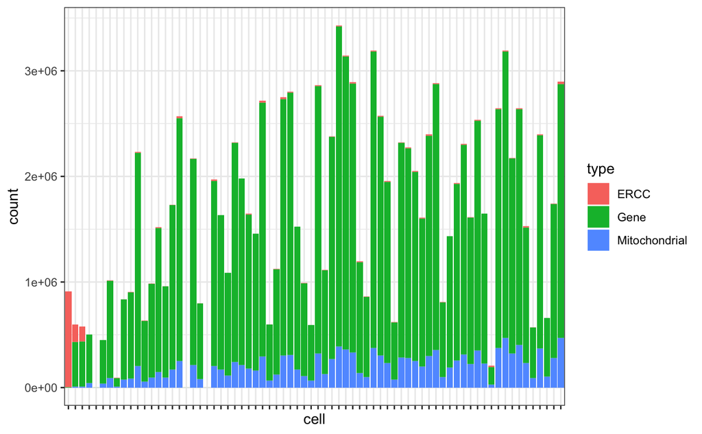

```r
mit_percent <- ERCC_mit_Gene_counts[type=="Mitochondrial", .(cell, mit_percent=count*100/total_count)]
ERCC_percent <- ERCC_mit_Gene_counts[type=="ERCC", .(cell, ERCC_percent=count*100/total_count)]
#sorted_cells = unique(ERCC_mit_Gene_counts[ order(total_count), cell])
sorted_cells = mit_percent[order(mit_percent), cell]
ERCC_mit_Gene_counts[, cell:=factor(cell, levels= sorted_cells )]
ggplot(ERCC_mit_Gene_counts) +
  geom_bar(aes(x=cell, y=count, fill=type), stat="identity", position = "stack") +
  theme_bw()+
  theme( axis.text.x=element_blank())
```

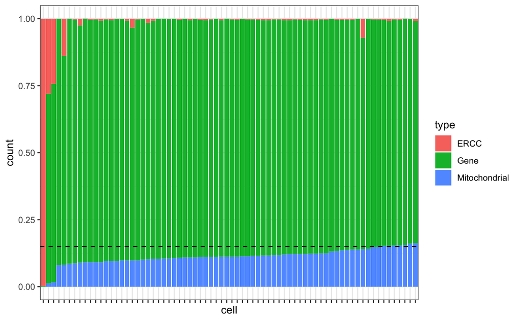

```r
ggplot(ERCC_mit_Gene_counts) +
  geom_bar(aes(x=cell, y=count, fill=type), stat="identity", position = "fill") +
  geom_hline(yintercept = 0.15, color="black", linetype="dashed") +
  theme_bw()+
  theme( axis.text.x=element_blank())
```

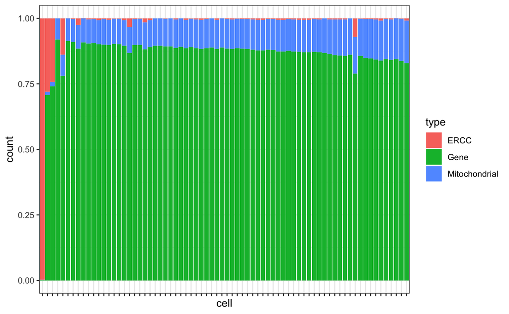

```r
ggplot(ERCC_mit_Gene_counts) +
  geom_bar(aes(x=cell, y=count, fill=type, group=(ERCC_percentage>=10)), stat="identity", position = "fill") +

  theme_bw()+
  theme( axis.text.x=element_blank())
```

Based on the previous plot, we defined ad oc filters for the cells

```r
filtered_out <- c(as.character(mit_percent[mit_percent>15, cell]), as.character( ERCC_percent[ERCC_percent>10, cell]), as.character(ERCC_mit_Gene_counts[total_count<5e5,cell]))
filtered_out <- unique(filtered_out)
```

Here are the results of such filters

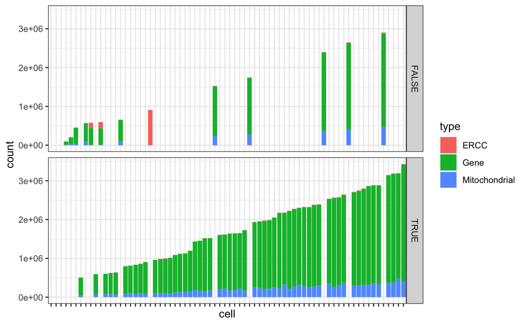

```r
sorted_cells = unique(ERCC_mit_Gene_counts[ order(total_count), cell])
ERCC_mit_Gene_counts[, cell:=factor(cell, levels= sorted_cells )]
ggplot(ERCC_mit_Gene_counts) +
  geom_bar(aes(x=cell, y=count, fill=type), stat="identity", position = "stack") +
  facet_grid(!cell %in% filtered_out ~ .) +
  theme_bw()+
  theme( axis.text.x=element_blank())
```

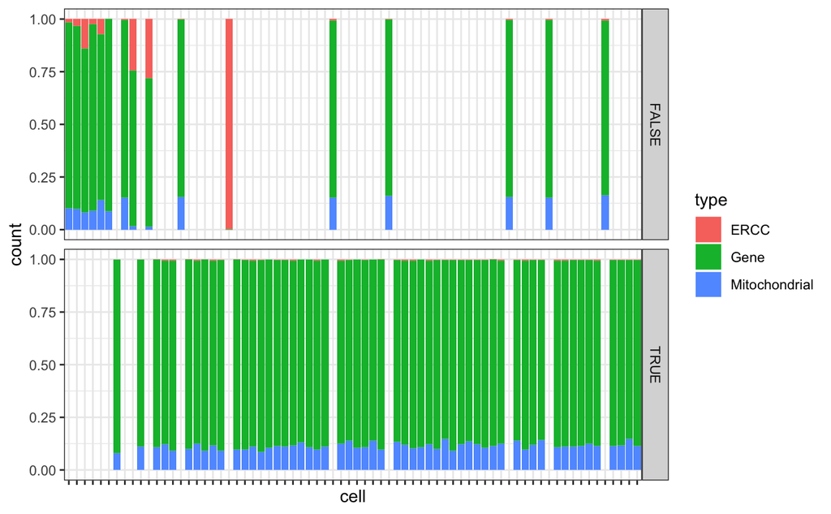

```r
ggplot(ERCC_mit_Gene_counts) +
  geom_bar(aes(x=cell, y=count, fill=type), stat="identity", position = "fill") +
  facet_grid(!cell %in% filtered_out ~ .) +
  theme_bw()+
  theme( axis.text.x=element_blank())
```

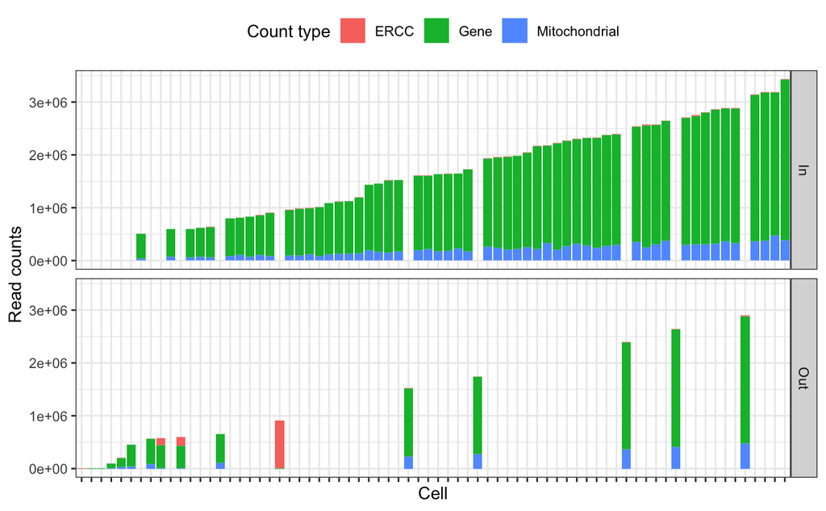

```r
ERCC_mit_Gene_counts[cell %in% filtered_out , filter:="Out" ]
ERCC_mit_Gene_counts[!cell %in% filtered_out , filter:="In" ]
Sup1.a <- ggplot(ERCC_mit_Gene_counts) +
  geom_bar(aes(x=cell, y=count, fill=type), stat="identity", position = "stack") +
  facet_grid(filter ~ .) +
  xlab("Cell")+
  ylab("Read counts")+
  theme_bw()+
  scale_fill_discrete(name = "Count type")+
  theme( axis.text.x=element_blank(),  legend.position = "top")
Sup1.a
```

```r
ERCC_mit_Gene_counts[, percentage:= count*100/total_count]
ERCC_mit_Gene_counts_dcast <- dcast(ERCC_mit_Gene_counts[, c("cell",  "type", "percentage")], cell ~ type)
```

# Filtering and TPM normalization

```r
Total_cell_counts <- ERCC_mit_Gene_counts$total_count
names(Total_cell_counts) <-  ERCC_mit_Gene_counts$cell
TOTAL_gene_count_melted_filtered <- TOTAL_gene_count_melted[!cell %in%  filtered_out, ]
TOTAL_gene_count_melted_filtered <- merge(TOTAL_gene_count_melted_filtered, gene_lenght, by="Geneid")
TOTAL_gene_count_melted_filtered[, RPK:= count*1e3/Length]
TOTAL_gene_count_melted_filtered[, Total_RPK:=sum(RPK), by=cell]
TOTAL_gene_count_melted_filtered[, TPM:= RPK*1e6/Total_RPK]
TOTAL_gene_count_melted_filtered$total_counts <- Total_cell_counts[TOTAL_gene_count_melted_filtered$cell]
TOTAL_gene_count_melted_filtered[, PM_scaling:=total_counts/1e6]
TOTAL_gene_count_melted_filtered[, RPKM:= count*1e3/(PM_scaling*Length) ]
TOTAL_gene_count_melted_filtered[, log_total_count:=log10(sum(count)), by=cell]
TOTAL_gene_count_filtered <- dcast(TOTAL_gene_count_melted_filtered,  value.var = "RPKM", formula = Geneid ~ cell)
n = ncol(TOTAL_gene_count_filtered)
TOTAL_gene_count_filtered_matrix <- as.matrix(TOTAL_gene_count_filtered)
row.names( TOTAL_gene_count_filtered_matrix) <- TOTAL_gene_count_filtered$Geneid
TOTAL_gene_count_filtered_matrix <- as.matrix(TOTAL_gene_count_filtered_matrix)[, 2:n]
mode(TOTAL_gene_count_filtered_matrix) <- 'numeric'
TOTAL_gene_count_filtered_raw_counts <- dcast(TOTAL_gene_count_melted_filtered,  value.var = "count", formula = Geneid ~ cell)
TOTAL_gene_count_filtered_matrix_raw_counts <- as.matrix(TOTAL_gene_count_filtered_raw_counts)
row.names( TOTAL_gene_count_filtered_matrix_raw_counts) <- TOTAL_gene_count_filtered$Geneid
TOTAL_gene_count_filtered_matrix_raw_counts <- as.matrix(TOTAL_gene_count_filtered_matrix_raw_counts)[, 2:n]
mode(TOTAL_gene_count_filtered_matrix_raw_counts) <- 'numeric'
```

Building the single cell experiment object and performing PCA

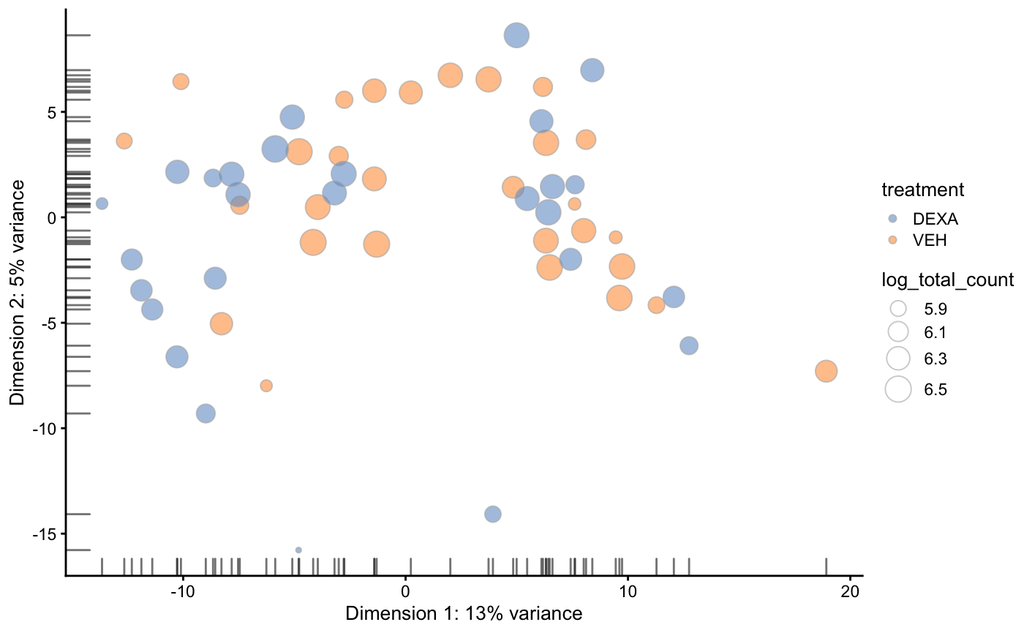

```r
library(SingleCellExperiment)
library(SC3)
library(scater)
#TOTAL_gene_count_melted_filtered[]
cell_log_counts <- TOTAL_gene_count_melted_filtered[, .(log_total_count=log10(sum(count)) ), by=cell]
filtered_cell_metadata <- merge(metadata, cell_log_counts, by.x="sample_file", by.y="cell")
filtered_cell_metadata <- merge(filtered_cell_metadata, ERCC_mit_Gene_counts_dcast, by.x="sample_file", by.y="cell")
ann <- as.data.frame( filtered_cell_metadata[  ,  c("treatment", "log_total_count", "ERCC", "Mitochondrial")] )
row.names(ann) <- filtered_cell_metadata[  ,  sample_file]
sce <- SingleCellExperiment(
    assays = list(
        counts = TOTAL_gene_count_filtered_matrix,
        logcounts = log2(TOTAL_gene_count_filtered_matrix + 1)
    ),
    colData = ann
)
# define feature names in feature_symbol column
rowData(sce)$feature_symbol <- rownames(sce)
# remove features with duplicated names
sce <- sce[!duplicated(rowData(sce)$feature_symbol), ]
# define spike-ins
isSpike(sce, "ERCC") <- grepl("ERCC", rowData(sce)$feature_symbol)
scater::plotPCA(sce, colour_by = "treatment", size="log_total_count")
```

Extracting PCA results

```r
PCA <- runPCA(sce, colour_by = "treatment", size="log_total_count")
PCA <- as.data.frame(reducedDim(PCA))
PCA$Cell <- row.names(PCA)
PCA <- data.table(PCA)
```

Performing SC3 clustering, results can be interactivelly visuallised with `sc3_interactive(sce)` comand

```r
sce <- sc3(sce, ks = 2:3, biology = TRUE)
```

```
Setting SC3 parameters...
Calculating distances between the cells...
```

[output not shown]

[output not shown]

[output not shown]

[output not shown]

[output not shown]

```
loaded SC3 and set parent environment
loaded SC3 and set parent environment
loaded SC3 and set parent environment
```

[output not shown]

[output not shown]

[output not shown]

[output not shown]

```r
#sc3_interactive(sce)
```

Incorporating clustering information into the PCA

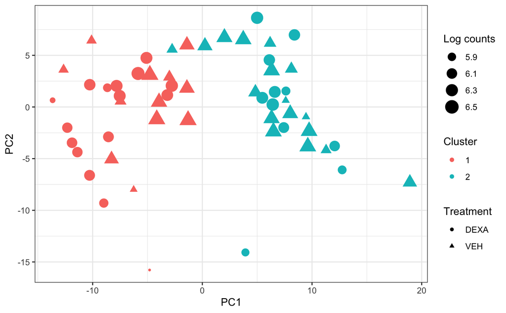

```r
sce_clustering <- as.data.frame(colData(sce))
sce_clustering$Cell <- row.names(sce_clustering)
sce_clustering <- data.table(sce_clustering)
PCA <- merge(sce_clustering, PCA, by="Cell")
sup1.b <- ggplot(PCA) +
  geom_point(aes(PC1, PC2, colour=sc3_2_clusters, shape=treatment, size=log_total_count)) +
  theme_bw() +
  labs(size="Log counts",col="Cluster", shape="Treatment")
sup1.b
```

Ploting SC3 clustering resutls

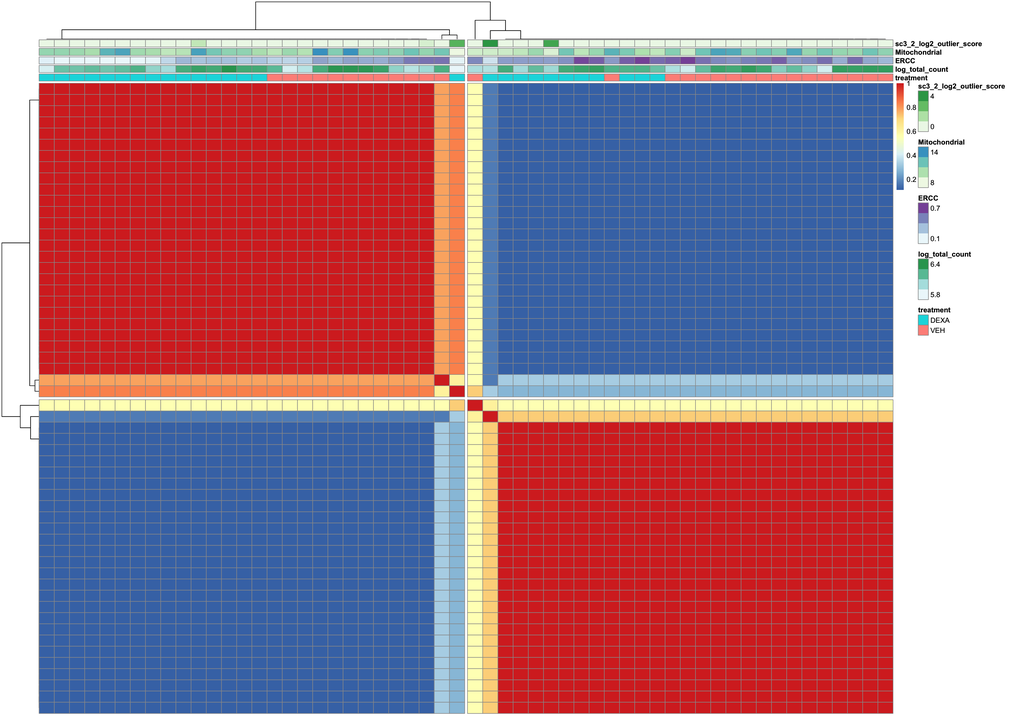

```r
fig5.b <- sc3_plot_consensus(
    sce, k = 2,
    show_pdata = c(
        "treatment",
        "sc3_2_log2_outlier_score",
        "log_total_count",
        "ERCC",
        "Mitochondrial"

    )
)
fig5.b
```

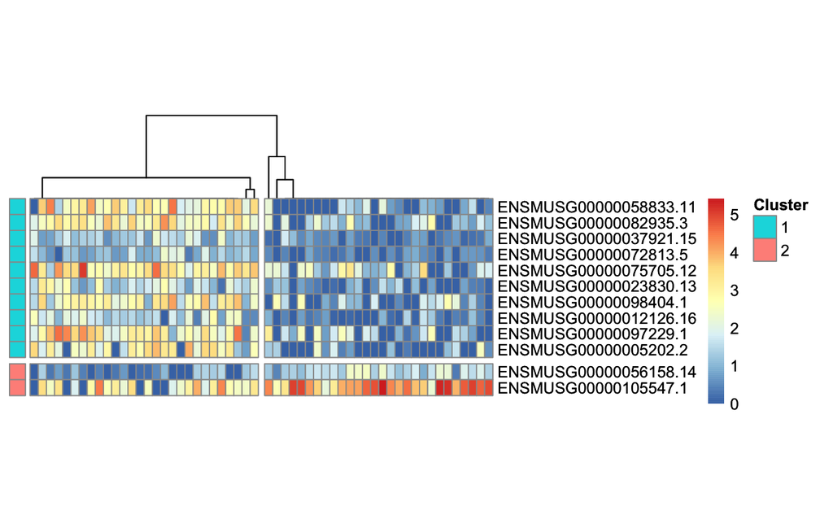

```r
sup1.c <- sc3_plot_markers(sce, k = 2)
sup1.c
```

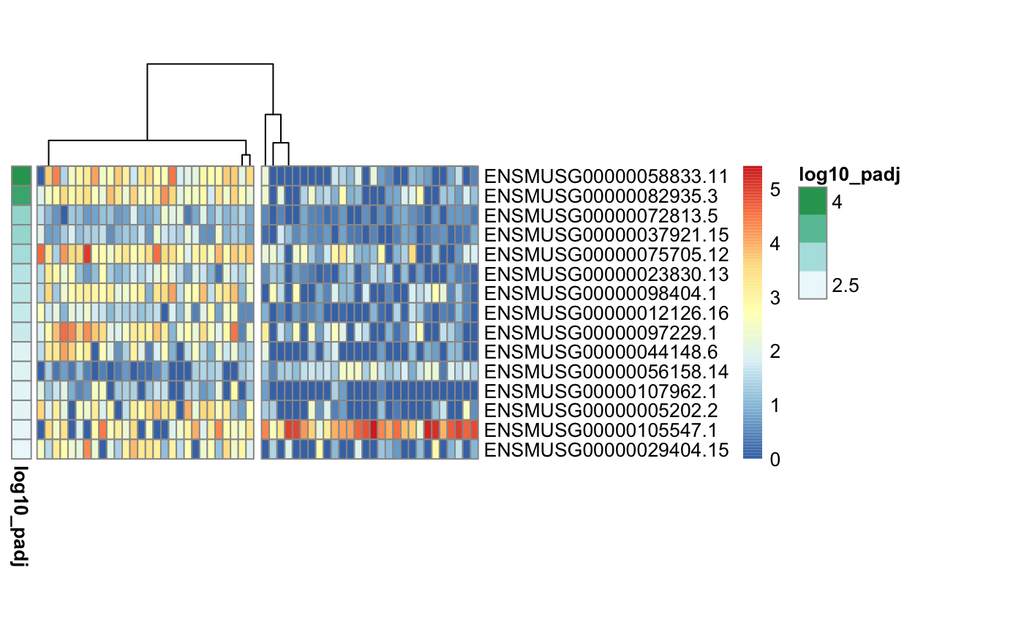

```r
sc3_plot_de_genes(sce, k = 2)
```

```r
col_data <- as.data.frame(colData(sce))
col_data$cell <- row.names(col_data)
col_data <- data.table(col_data)
cluster1 <- col_data[sc3_2_clusters==1 & sc3_2_log2_outlier_score<=3, ]
cluster2 <- col_data[sc3_2_clusters==2 &  sc3_2_log2_outlier_score<=3, ]
cluster1[, "cell"]
```

```
           cell
 1: 24768_2#060
 2: 24768_2#077
 3: 24768_2#079
 4: 24768_2#081
 5: 24768_2#083
 6: 24768_2#087
 7: 24768_2#089
 8: 24768_2#091
 9: 24768_2#093
10: 24768_2#097
11: 24768_2#099
12: 24768_2#101
13: 24768_2#107
14: 24768_2#109
15: 24768_2#111
16: 24768_2#113
17: 24768_2#115
18: 24768_2#117
19: 24768_2#123
20: 24768_2#129
21: 24768_2#131
22: 24768_2#133
23: 24768_2#137
24: 24768_2#139
25: 24768_2#141
26: 24768_2#143
27: 24768_2#147
           cell
```

# Differential Expession analyses

```r
library(monocle)
library(biomaRt)
```

Filtering metadata and getting aditional gene information from biomart

```r
metadata_filtered <- metadata[ sample_file %in% colnames(TOTAL_gene_count_filtered), ]
metadata_filtered <- data.frame(metadata_filtered, row.names=metadata_filtered$sample_file)
```

```r
gene_table <- data.table(getBM(attributes=c('ensembl_gene_id_version',"ensembl_gene_id", "wikigene_description", "mgi_symbol"),filters = 'ensembl_gene_id_version', values = rownames(TOTAL_gene_count_filtered_matrix) , mart = ensembl))
```

[output not shown]

[output cut: 42 more lines]

[output not shown]

```r
gene_table <- gene_table[gene_table[ , .I[sample(.N,1)] , by = ensembl_gene_id_version]$V1]  #eliminating duplicates
gene_table <- as.data.frame(gene_table, row.names = gene_table$ensembl_gene_id_version)
gene_table$gene_short_name <- gene_table$mgi_symbol
```

Extracting relevant infromation from gene clusters and differentially expressed genes from SC3

```r
row_data <- as.data.frame(rowData(sce))
row_data <- data.table(row_data)
gene_markers <- row_data[sc3_2_markers_auroc>=0.85, ]
gene_DE <- row_data[sc3_2_de_padj<=0.05,]
gene_markers <- data.table(merge(gene_table, gene_markers, by.x='ensembl_gene_id_version', by.y='feature_symbol'))
gene_DE <- data.table(merge(gene_table, gene_DE, by.x='ensembl_gene_id_version', by.y='feature_symbol'))
gene_markers[sort(sc3_2_markers_auroc)]
```

```
Empty data.table (0 rows and 14 cols): ensembl_gene_id_version,ensembl_gene_id,wikigene_description,mgi_symbol,gene_short_name,sc3_gene_filter...
```

```r
write.table(gene_markers[sort(-sc3_2_markers_auroc)], file = "./output_tables/cluster_marker_info.txt", append = FALSE, quote = F, sep = " ",
            eol = "\n", na = "NA", dec = ".", row.names = F,
            col.names = TRUE, qmethod = c("escape", "double"),
            fileEncoding = "")
gene_DE[sort(sc3_2_de_padj)]
```

```
Empty data.table (0 rows and 14 cols): ensembl_gene_id_version,ensembl_gene_id,wikigene_description,mgi_symbol,gene_short_name,sc3_gene_filter...
```

```r
write.table( gene_DE , file = "./output_tables/cluster_DE_info.txt", append = FALSE, quote = F, sep = "\t",
            eol = "\n", na = "NA", dec = ".", row.names = F,
            col.names = TRUE, qmethod = c("escape", "double"),
            fileEncoding = "")
```

Generating countable for monocle analyses

```r
gene_count_monocle <- TOTAL_gene_count_filtered_matrix[gene_table$ensembl_gene_id_version, ]
row.names(gene_table) <- gene_table$ensembl_gene_id_version
rownames(metadata_filtered) <- metadata_filtered$sample_file
```

```r
#gene_table$gene_short_name <- gene_table$gene_name
pd <- new("AnnotatedDataFrame", data = metadata_filtered)
fd <- new("AnnotatedDataFrame", data = gene_table)
HSMM <- newCellDataSet(gene_count_monocle, phenoData = pd, featureData = fd, expressionFamily=VGAM::tobit() )
HSMM <- detectGenes(HSMM, min_expr = 0.1)
expressed_genes <- row.names(subset(fData(HSMM),
    num_cells_expressed >= 11))
expressed_genes_mart <- data.table(getBM(attributes=c('ensembl_gene_id_version', "mgi_symbol"),filters = 'ensembl_gene_id_version', values = expressed_genes , mart = ensembl))
```

[output not shown]

Attempting to incorporate Spike-ins data for the quantification

```r
ERCC_count_table <- TOTAL_gene_count_melted[startsWith(Geneid ,"ERCC"), ]
Gene_lenghts <- gene_lenght$Length
names(Gene_lenghts) <- gene_lenght$Geneid
ERCC_count_table$total_count <-  Total_cell_counts[ERCC_count_table$cell]
ERCC_count_table$lenght <-  Gene_lenghts[ERCC_count_table$Geneid]
ERCC_count_table[, PM_scaling:=total_count/1e6]
ERCC_count_table[, RPKM:= count*1e3/(PM_scaling*lenght) ]
ERCC_count_table[, Geneid:=substring(Geneid, 1, 10)]
ERCC_count_table_matrix <- dcast(ERCC_count_table,  value.var = "RPKM", formula = Geneid ~ cell)
n = ncol(ERCC_count_table_matrix)
ERCC_count_table_matrix <- as.matrix(ERCC_count_table_matrix)
row.names( ERCC_count_table_matrix) <- ERCC_count_table_matrix[,1]
ERCC_count_table_matrix <- as.matrix(ERCC_count_table_matrix)[, 2:n]
mode(ERCC_count_table_matrix) <- 'numeric'
```

```r
input.ERCC.annotation<-read.delim("data/ERCC_Controls_Analysis.txt", header=T)
colnames(input.ERCC.annotation)<-c("Resort_ID","ERCC_ID","subgroup","conc_attomoles_ul_Mix1","conc_attomoles_ul_Mix2","exp_fch_ratio","log2_Mix1_Mix2")
rownames(input.ERCC.annotation)<-input.ERCC.annotation[,"ERCC_ID"]
ERCC_Controls_Annotation <- read_delim("data//ERCC_Controls_Annotation.txt",
    "\t", escape_double = FALSE, trim_ws = TRUE)
ERCC_Controls_Analysis <- read_delim("data//ERCC_Controls_Analysis.txt",
    "\t", escape_double = FALSE, trim_ws = TRUE)
colnames(ERCC_Controls_Analysis) <- c("sort_ID", "ERCC_ID", "subgroup", "conc_attomoles_ul_Mix1", "conc_attomoles_ul_Mix2", "exp_fch_ratio", "log2(Mix_1/Mix_2)")
ERCC_Controls_Annotation_matrix <- as.matrix(ERCC_Controls_Annotation)
ERCC_Controls_Analysis_matrix <- as.matrix(ERCC_Controls_Analysis)
# Next, use it to estimate RNA counts
rpc_matrix <- relative2abs(HSMM, method = "num_genes")
```

[output not shown]

```r
# Now, make a new CellDataSet using the RNA counts
```

Simulating spike-ins

```r
rpc_matrix <- relative2abs(HSMM, method = "num_genes")

HSMM <- newCellDataSet(as(as.matrix(rpc_matrix), "sparseMatrix"),
                phenoData = pd,
                featureData = fd,
                lowerDetectionLimit = 0.5,
                expressionFamily = negbinomial.size())
```

To run the analysis with real Spike-ins, activate the following code. However, the results obtained in this case with simulated spike ins are much better quality and were the ones we used for Gapp et al 2020

```r
#rpc_matrix <- relative2abs(HSMM, method = "num_genes", ERCC_controls=ERCC_count_table_matrix[,rownames(metadata_filtered)], ERCC_annotation=input.ERCC.annotation, return_all=F)


#colnames(rpc_matrix) <- rownames(metadata_filtered)
#rownames(rpc_matrix) <- rownames(gene_table)



#HSMM <- newCellDataSet(as(as.matrix(rpc_matrix), "sparseMatrix"),
#                phenoData = pd,
#                featureData = fd,
#                lowerDetectionLimit = 0.5,
#                expressionFamily = negbinomial.size())
```

```r
diff_test_res <- differentialGeneTest(HSMM, fullModelFormulaStr = "~treatment", relative_expr = FALSE, cores = 3)


fwrite(diff_test_res, "total.diff.txt", sep="\t" )
```

```r
sig_genes <- subset(diff_test_res, qval < 0.05)
sig_genes <- data.table(sig_genes)

sig_genes_expressed_genes <- sig_genes[ensembl_gene_id_version %in% expressed_genes, ]
sig_genes_expressed_genes <- sig_genes_expressed_genes[order(pval ),]
sig_genes_expressed_genes[order(mgi_symbol),c("ensembl_gene_id_version", "gene_short_name", "wikigene_description")]


paste(sig_genes_expressed_genes$gene_short_name, collapse=" ")
```

```r
HSMM <- detectGenes(HSMM, min_expr = 0.1)

to_be_tested <- row.names(subset(fData(HSMM),
              gene_short_name %in% head(sig_genes$gene_short_name, 10)))








cds_subset <- HSMM[to_be_tested,]

plot_genes_jitter(cds_subset,
                  grouping = "treatment",
                  color_by = "treatment",
                  nrow= 1,
                  ncol = NULL,
                  plot_trend = TRUE)


pData(cds_subset)

cds_subset
```

```r
to_be_tested <- row.names(subset(fData(HSMM),
              gene_short_name %in% head(sig_genes_total$gene_short_name, 10) ))


cds_subset <- HSMM[to_be_tested,]
plot_genes_jitter(cds_subset,
                  grouping = "treatment",
                  color_by = "treatment",
                  nrow= 1,
                  ncol = NULL,
                  plot_trend = TRUE)
```

# Cluster 1

```r
TOTAL_gene_count_filtered_matrix_c1 <- gene_count_monocle[, cluster1[, cell]]


metadata_filtered_c1 <- metadata[sample_file %in% cluster1[, cell], ]
metadata_filtered_c1 <- data.frame(metadata_filtered_c1, row.names=metadata_filtered_c1$sample_file)

rownames(metadata_filtered_c1) <- metadata_filtered_c1$sample_file
rownames(metadata_filtered_c1) <- metadata_filtered_c1$sample_file
```

```r
dim(metadata_filtered_c1)
```

```r
pd_c1 <- new("AnnotatedDataFrame", data = metadata_filtered_c1)
fd_c1 <- new("AnnotatedDataFrame", data = gene_table)
HSMM_c1 <- newCellDataSet(TOTAL_gene_count_filtered_matrix_c1, phenoData = pd_c1, featureData = fd_c1, expressionFamily=tobit() )


HSMM_c1 <- detectGenes(HSMM_c1, min_expr = 0.1)
#expressed_genes <- row.names(subset(fData(HSMM),
#    num_cells_expressed >= 11))
```

```r
fwrite(data.table(expressed_genes_mart$mgi_symbol), file="./expressed_genes.txt", col.names=F)
```

```r
rpc_matrix_c1 <- relative2abs(HSMM_c1, method = "num_genes")

HSMM_c1 <- newCellDataSet(as(as.matrix(rpc_matrix_c1), "sparseMatrix"),
                phenoData = pd_c1,
                featureData = fd_c1,
                lowerDetectionLimit = 0.5,
                expressionFamily = negbinomial.size())
```

```r
diff_test_res_c1 <- differentialGeneTest(HSMM_c1, fullModelFormulaStr = "~treatment", relative_expr = F)

sig_genes_c1 <- subset(diff_test_res_c1, qval < 0.05)
sig_genes_c1 <- data.table(sig_genes_c1)

fwrite(diff_test_res_c1, "cluster1.diff.txt", sep="\t")
```

# Cluster2

```r
TOTAL_gene_count_filtered_matrix_c2 <- gene_count_monocle[, cluster2[, cell]]


metadata_filtered_c2 <- metadata[sample_file %in% cluster2[, cell], ]
metadata_filtered_c2 <- data.frame(metadata_filtered_c2, row.names=metadata_filtered_c2$sample_file)

rownames(metadata_filtered_c2) <- metadata_filtered_c2$sample_file
rownames(metadata_filtered_c2) <- metadata_filtered_c2$sample_file
```

```r
pd_c2 <- new("AnnotatedDataFrame", data = metadata_filtered_c2)
fd_c2 <- new("AnnotatedDataFrame", data = gene_table)
HSMM_c2 <- newCellDataSet(TOTAL_gene_count_filtered_matrix_c2, phenoData = pd_c2, featureData = fd_c2, expressionFamily=tobit() )


HSMM_c2 <- detectGenes(HSMM_c2, min_expr = 0.1)
#expressed_genes <- row.names(subset(fData(HSMM),
#    num_cells_expressed >= 11))
```

```r
rpc_matrix_c2 <- relative2abs(HSMM_c2, method = "num_genes")

HSMM_c2 <- newCellDataSet(as(as.matrix(rpc_matrix_c2), "sparseMatrix"),
                phenoData = pd_c2,
                featureData = fd_c2,
                lowerDetectionLimit = 0.5,
                expressionFamily = negbinomial.size())
```

```r
diff_test_res_c2 <- differentialGeneTest(HSMM_c2, fullModelFormulaStr = "~treatment", relative_expr = F)

sig_genes_c2 <- subset(diff_test_res_c2, qval < 0.05)
sig_genes_c2 <- data.table(sig_genes_c2)

fwrite(diff_test_res_c2, "cluster2.diff.txt", sep="\t" )
```

## Pseudotime

```r
HSMM



gene_DE <- data.table(gene_DE)

gene_DE[order(sc3_2_de_padj)][, ensembl_gene_id]



HSMM <- setOrderingFilter(HSMM, gene_DE[order(sc3_2_de_padj)][, ensembl_gene_id])

HSMM3 <- updateCDS(HSMM)


HSMM3 <- estimateSizeFactors(HSMM3)
HSMM3 <- estimateDispersions(HSMM3)

plot_ordering_genes(HSMM3)


data.table(getBM(attributes=c('ensembl_gene_id',"ensembl_transcript_id_version", 'entrezgene', "wikigene_description", "mgi_symbol"),filters = 'ensembl_transcript_id', values = c("ENSMUST00000117661") , mart = ensembl))

cat( gene_DE[, mgi_symbol], sep="\n")
```

```r
HSMM <- reduceDimension(HSMM, max_components = 2,
    method = 'DDRTree')

#HSMM <- reduceDimension(my_cds, max_components = 2, num_dim = 5,
#                          reduction_method = 'tSNE', verbose = TRUE)
```

```r
HSMM3 <- preprocessCDS(HSMM3)

HSMM3 <- reduceDimension(HSMM3, method = 'tSNE')

HSMM3 <- partitionCells(HSMM3)

HSMM3 <- setOrderingFilter(HSMM3, gene_DE[order(sc3_2_de_padj)][, ensembl_gene_id])


HSMM3 <- learnGraph(HSMM3,  RGE_method = 'SimplePPT',verbose=T)


plot_cell_trajectory(HSMM3)
```

```r
HSMM <- orderCells(HSMM)
```

```r
paste(gene_DE[, mgi_symbol], sep=" ")

cat( unique(gene_DE[sc3_2_markers_clusts==1, mgi_symbol]), sep=' ')
```

## Intersection

```r
library(limma)


total_sig_matrix <- cbind(as.numeric(diff_test_res$qval<=0.05),
      as.numeric(diff_test_res_c1$qval<=0.05),
      as.numeric(diff_test_res_c2$qval<=0.05)
)


colnames(total_sig_matrix) <- c("Total", "Cluster1", "Cluster2")

row.names(total_sig_matrix) <- diff_test_res$gene_short_name

total_sig_matrix_counts <- vennCounts(total_sig_matrix)

vennDiagram(total_sig_matrix_counts)


names(which(rowSums(total_sig_matrix)==3))



two_clusters_info <-  data.table (diff_test_res[which(rowSums(total_sig_matrix[, 2:3])==1), c("gene_short_name", "wikigene_description", "ensembl_gene_id_version")])


write.table(two_clusters_info, file = "./two_clusters_info.txt", append = FALSE, quote = F, sep = " ",
            eol = "\n", na = "NA", dec = ".", row.names = F,
            col.names = TRUE, qmethod = c("escape", "double"),
            fileEncoding = "")


cat(two_clusters_info[, gene_short_name], sep="\n")
```

```r
two_clusters_info
```

```r
total_sig_table <- data.table(total_sig_matrix)
total_sig_table[, mgi_symbol:=rownames(total_sig_matrix)]
total_sig_table <- total_sig_table[ , c("mgi_symbol", "Total", "Cluster1", "Cluster2")]


total_sig_table[, `:=`(Total=as.logical(Total),
                Cluster1=as.logical(Cluster1),
                Cluster2=as.logical(Cluster2))]


write.table(total_sig_table, file = "./total_sig_table.txt", append = FALSE, quote = F, sep = "\t",
            eol = "\n", na = "NA", dec = ".", row.names = F,
            col.names = TRUE, qmethod = c("escape", "double"),
            fileEncoding = "")
```

```r
total_sig_table[ , C1C2:=0]

total_sig_table[ mgi_symbol %in% gene_DE[, mgi_symbol] , C1C2:=1]


total_sig_matrix_C1C2_counts <- vennCounts(total_sig_table[, c(2:5)])

vennDiagram(total_sig_matrix_C1C2_counts)
```

```r
total_sig_table[Cluster1>0,]
```

```r
library(UpSetR)

diff_intersection <- list(Total = total_sig_table[Total>0, mgi_symbol],
     Cluster1 = total_sig_table[Cluster1>0, mgi_symbol],
     Cluster2 = total_sig_table[Cluster2>0, mgi_symbol])


fig5.c1 <- upset(fromList(diff_intersection), order.by = "freq", nsets = 5, keep.order = T)
fig5.c1
```

```r
gg_color_hue <- function(n) {
  hues = seq(15, 375, length = n + 1)
  hcl(h = hues, l = 65, c = 100)[1:n]
}
```

```r
library(eulerr)

diff_intersection <- euler(c("Total" = 58,
                                    "Total&Cluster1" = 19,
                                    "Total&Cluster2" = 19,
                                    "Cluster2" = 15,
                                    "Cluster1" = 8,
                                    "Total&Cluster1&Cluster2" = 7,
                                    "Cluster2&Cluster1" = 4))



fig5.c2 <- plot(diff_intersection, font=2, cex=2, alpha=0.5,
     fill=gg_color_hue(3), quantities = list(fontsize = 0))

fig5.c2
```

```r
plot_genes_jitter_non_log <- function (cds_subset, grouping = "State", min_expr = NULL, cell_size = 0.75,
    nrow = NULL, ncol = 1, panel_order = NULL, color_by = NULL,
    plot_trend = FALSE, label_by_short_name = TRUE, relative_expr = TRUE)
{
    if (cds_subset@expressionFamily@vfamily %in% c("negbinomial",
        "negbinomial.size")) {
        integer_expression <- TRUE
    }
    else {
        integer_expression <- FALSE
        relative_expr <- TRUE
    }
    if (integer_expression) {
        cds_exprs <- exprs(cds_subset)
        if (relative_expr) {
            if (is.null(sizeFactors(cds_subset))) {
                stop("Error: to call this function with relative_expr=TRUE, you must call estimateSizeFactors() first")
            }
            cds_exprs <- Matrix::t(Matrix::t(cds_exprs)/sizeFactors(cds_subset))
        }
        cds_exprs <- reshape2::melt(round(as.matrix(cds_exprs)))
    }
    else {
        cds_exprs <- exprs(cds_subset)
        cds_exprs <- reshape2::melt(as.matrix(cds_exprs))
    }
    if (is.null(min_expr)) {
        min_expr <- cds_subset@lowerDetectionLimit
    }
    colnames(cds_exprs) <- c("f_id", "Cell", "expression")
    cds_exprs$expression[cds_exprs$expression < min_expr] <- min_expr
    cds_pData <- pData(cds_subset)
    cds_fData <- fData(cds_subset)
    cds_exprs <- merge(cds_exprs, cds_fData, by.x = "f_id", by.y = "row.names")
    cds_exprs <- merge(cds_exprs, cds_pData, by.x = "Cell", by.y = "row.names")
    cds_exprs$adjusted_expression <- log10(cds_exprs$expression)
    if (label_by_short_name == TRUE) {
        if (is.null(cds_exprs$gene_short_name) == FALSE) {
            cds_exprs$feature_label <- cds_exprs$gene_short_name
            cds_exprs$feature_label[is.na(cds_exprs$feature_label)] <- cds_exprs$f_id
        }
        else {
            cds_exprs$feature_label <- cds_exprs$f_id
        }
    }
    else {
        cds_exprs$feature_label <- cds_exprs$f_id
    }
    if (is.null(panel_order) == FALSE) {
        cds_exprs$feature_label <- factor(cds_exprs$feature_label,
            levels = panel_order)
    }
    q <- ggplot(aes_string(x = grouping, y = "expression"), data = cds_exprs)
    if (is.null(color_by) == FALSE) {
        q <- q + geom_jitter(aes_string(color = color_by), size = I(cell_size))
    }
    else {
        q <- q + geom_jitter(size = I(cell_size))
    }
    if (plot_trend == TRUE) {
        q <- q + stat_summary(aes_string(color = color_by), fun.data = "mean_cl_boot",
            size = 0.35)
        q <- q + stat_summary(aes_string(x = grouping, y = "expression",
            color = color_by, group = color_by), fun.data = "mean_cl_boot",
            size = 0.35, geom = "line")
    }
    q <- q  + facet_wrap(~feature_label, nrow = nrow,
        ncol = ncol, scales = "free_y")
    if (min_expr < 1) {
        q <- q + expand_limits(y = c(min_expr, 1))
    }
    q <- q + ylab("Expression") + xlab(grouping) + theme_bw() + theme(legend.position = "top")
    #q <- q + monocle_theme_opts()
    data.table(cds_exprs)
}
```

```r
library(Hmisc)



HSMM_c1 <- detectGenes(HSMM_c1, min_expr = 0.01)



#to_be_tested_c1 <- row.names(subset(fData(HSMM),
#              gene_short_name %in% total_sig_table[Cluster1 == TRUE , gene]  ))


gene_list <- c("Bcap31", "Hprt", "Rbbp7", "Tcl1")
to_be_tested_c1 <- row.names(subset(fData(HSMM),
              gene_short_name %in% gene_list  ))


cds_subset_c1 <- HSMM_c1[to_be_tested_c1,]

fig5.cluster1 <- plot_genes_jitter_non_log(cds_subset_c1,
                  grouping = "treatment",
                  color_by = "treatment",
                  nrow= 1,
                  ncol = NULL,
                  plot_trend = TRUE,
                  relative_expr = FALSE)
```

```r
library(Hmisc)

HSMM_c2 <- detectGenes(HSMM_c2, min_expr = 0.01)



#to_be_tested_c2 <- row.names(subset(fData(HSMM),
#              gene_short_name %in% total_sig_table[Cluster2 == TRUE , gene]  ))


gene_list <- c("Bcap31", "Hprt", "Rbbp7", "Tcl1")
to_be_tested_c2 <- row.names(subset(fData(HSMM),
              gene_short_name %in% gene_list  ))





cds_subset_c2 <- HSMM_c2[to_be_tested_c2,]

fig5.cluster2 <- plot_genes_jitter_non_log(cds_subset_c2,
                  grouping = "treatment",
                  color_by = "treatment",
                  nrow= 1,
                  ncol = NULL,
                  plot_trend = TRUE,
                  relative_expr = FALSE)
```

```r
diff_test_res_c1.table <- data.table(diff_test_res_c1) #[mgi_symbol %in% unique(fig5.clusters.total$mgi_symbol),  ]
diff_test_res_c2.table <- data.table(diff_test_res_c2) #[mgi_symbol %in% unique(fig5.clusters.total$mgi_symbol),  ]

diff_test_res_c1.table[, Cluster:="1"]
diff_test_res_c2.table[, Cluster:="2"]

diff_test_res.genes.table <- rbind(diff_test_res_c1.table, diff_test_res_c2.table)

diff_test_res.genes.table[ , sig:="NA"]
diff_test_res.genes.table[ qval<=0.05 , sig:="*"]
diff_test_res.genes.table[ qval<=0.01, sig:="**"]
diff_test_res.genes.table[ qval<=0.001, sig:="***"]

diff_test_res.genes.table[, `:=`(start="VEH", end="DEXA", feature_label=mgi_symbol ) ]
```

```r
fig5.clusters.total$treatment <- factor(fig5.clusters.total$treatment, levels=c("VEH","DEXA"))

fig5.clusters.total.y_pos <-  fig5.clusters.total[ , .(  y_pos=(max(expression)-min(expression))*0.85 + min(expression)  ), by=c("feature_label", "Cluster")]

diff_test_res.genes.table <- merge(diff_test_res.genes.table[Cluster=="1", ], fig5.clusters.total.y_pos, by=c("feature_label", "Cluster"))


fig5.cluster1$treatment <- factor(fig5.cluster1$treatment , levels=c("VEH", "DEXA"))

fig5.f <- ggplot(fig5.cluster1, aes(treatment, expression)) +
  geom_jitter(  aes(colour=treatment) ) +
  stat_summary( aes(colour=treatment), fun.data = "mean_cl_boot",  size = 0.5, shape=4) +
  facet_wrap( . ~ feature_label, scales = "free_y", nrow=1, ) +
  theme_bw() +
  theme(legend.position = "top") +
  geom_signif(data=diff_test_res.genes.table[sig!="NA", ],
              aes(xmin=start, xmax=end, annotations=sig, y_position=y_pos),
              manual=TRUE)

fig5.f
```

```r
subset_sup.C1 <- HSMM_c1[to_be_tested_sup,]
subset_sup.C2 <- HSMM_c2[to_be_tested_sup,]

sup_jitter.C1 <- plot_genes_jitter_non_log(subset_sup.C1,
                  grouping = "treatment",
                  color_by = "treatment",
                  nrow= 1,
                  ncol = NULL,
                  plot_trend = TRUE,
                  relative_expr = FALSE)


sup_jitter.C2 <- plot_genes_jitter_non_log(subset_sup.C2,
                  grouping = "treatment",
                  color_by = "treatment",
                  nrow= 1,
                  ncol = NULL,
                  plot_trend = TRUE,
                  relative_expr = FALSE)



sup_jitter.C1[, Cluster:="C1" ]
sup_jitter.C2[, Cluster:="C2" ]

sup_jitter.total <- rbind(sup_jitter.C1, sup_jitter.C2)



sup_jitter.total$Treatment <- factor(sup_jitter.total$treatment, levels=c("VEH","DEXA"))

sup_jitter.total.y_pos <-  sup_jitter.total[ , .(  y_pos=(max(expression)-min(expression))*0.85 + min(expression)  ), by=c("feature_label", "Cluster")]

diff_test_res.genes.table[Cluster=="1", Cluster:="C1"]
diff_test_res.genes.table[Cluster=="2", Cluster:="C2"]

sup_jitter.total.diff_test_res.genes.table <- merge( diff_test_res.genes.table, sup_jitter.total.y_pos, by=c("feature_label", "Cluster"))


sup_jitter.total[feature_label=="", feature_label:=ensembl_gene_id]
sup_jitter.total.diff_test_res.genes.table[feature_label=="", feature_label:=ensembl_gene_id]

remove <- sup_jitter.total.diff_test_res.genes.table[sig=="NA", .N, by="feature_label"][N>1, feature_label]


ggplot(sup_jitter.total[!feature_label %in% remove, ], aes(treatment, expression)) +
  geom_jitter(  aes(colour=treatment) ) +
  stat_summary( aes(colour=treatment), fun.data = "mean_cl_boot",  size = 0.5, shape=4) +
  facet_wrap(  feature_label ~ Cluster , scales = "free_y", ncol=6, ) +
  theme_bw() +
  xlab("Treatment") +
  theme(legend.position = "top") +
  geom_signif(data=sup_jitter.total.diff_test_res.genes.table[sig!="NA" & !feature_label %in% remove , ],
              aes(xmin=start, xmax=end, annotations=sig, y_position=y_pos),
              manual=TRUE) +
    labs(colour = "Treatment")
```

### Target Scan

```r
library(readxl)


get_gene_miRNA_targets <- function(TargetScan_excel){

  miR.targets <- read_excel(TargetScan_excel)
  miR.targets.gene_table <- data.table(getBM(attributes=c('ensembl_gene_id_version','ensembl_gene_id', 'ensembl_gene_id_version', 'entrezgene', "wikigene_description", "mgi_symbol"),filters = 'mgi_symbol', values = miR.targets$`Target gene` , mart = ensembl))

  miR.targets.gene_table[, mgi_symbol]


}
```

```r
miR30.names <- get_gene_miRNA_targets("~/Google_Drive/Results/Kathi/TargetScan/list q<0.05/TargetScan7.1__miR-30-5p_384-5p.predicted_targets.xlsx")
miR7210.names <- get_gene_miRNA_targets("~/Google_Drive/Results/Kathi/TargetScan/list q<0.05/TargetScan7.1__miR-7210-5p.predicted_targets.xlsx")
miR411.names <- get_gene_miRNA_targets("~/Google_Drive/Results/Kathi/TargetScan/list q<0.05/TargetScan7.1__miR-411-5p.predicted_targets.xlsx")
miR7232.names <- get_gene_miRNA_targets("~/Google_Drive/Results/Kathi/TargetScan/list q<0.05/TargetScan7.1__miR-7232-3p.predicted_targets.xlsx")

miR150.names <- get_gene_miRNA_targets("~/Google_Drive/Results/Kathi/TargetScan/lists q>0.05<0.1/TargetScan7.1__miR-150-5p.predicted_targets.xlsx")
miR7241.names <- get_gene_miRNA_targets("~/Google_Drive/Results/Kathi/TargetScan/lists q>0.05<0.1/TargetScan7.1__miR-7241-3p.predicted_targets.xlsx")
miR328.names <- get_gene_miRNA_targets("~/Google_Drive/Results/Kathi/TargetScan/lists q>0.05<0.1/TargetScan7.1__miR-328-3p.predicted_targets.xlsx")
miR871.names <- get_gene_miRNA_targets("~/Google_Drive/Results/Kathi/TargetScan/lists q>0.05<0.1/TargetScan7.1__miR-871-3p.predicted_targets.xlsx")
miR7233.names <- get_gene_miRNA_targets("~/Google_Drive/Results/Kathi/TargetScan/lists q>0.05<0.1/TargetScan7.1__miR-7233-3p.predicted_targets.xlsx")
miR872.names <- get_gene_miRNA_targets("~/Google_Drive/Results/Kathi/TargetScan/lists q>0.05<0.1/TargetScan7.1__miR-872-5p.predicted_targets.xlsx")
```

```r
target_len <- c(length(miR30.names),
                length(miR7210.names),
                length(miR411.names),
                length(miR7232.names),
                length(miR150.names),
                length(miR7241.names),
                length(miR328.names),
                length(miR871.names),
                length(miR7233.names),
                length(miR872.names)
                )
```

```r
total_sig_table[, `:=`(
                miR30 = gene %in% miR30.names,
                miR7210= gene %in% miR7210.names,
                miR411= gene %in% miR411.names,
                miR7232= gene %in% miR7232.names,
                miR150= gene %in% miR150.names,
                miR7241= gene %in% miR7241.names,
                miR328= gene %in% miR328.names,
                miR871= gene %in% miR871.names,
                miR7233= gene %in% miR7233.names,
                miR872= gene %in% miR872.names
                )]
```

```r
count_matrix <- vennCounts(as.matrix(total_sig_table[, c(2,3,4,5)]))


  vennCounts(as.matrix(total_sig_table[, c(2,3,4,5)]))
```

```r
nrow(total_sig_table[miR30==TRUE, ])

nrow(total_sig_table[Total==TRUE & miR30==TRUE, ])

nrow(total_sig_table[ Total==TRUE ,  ])

nrow(total_sig_table)

s <- length(miR30)
m <- length(miR30)
```

```r
vennDiagram(vennCounts(as.matrix(total_sig_table[, c(2,3,4,5)])))
vennDiagram(vennCounts(as.matrix(total_sig_table[, c(2,3,4,6)])))
vennDiagram(vennCounts(as.matrix(total_sig_table[, c(2,3,4,7)])))
vennDiagram(vennCounts(as.matrix(total_sig_table[, c(2,3,4,8)])))
vennDiagram(vennCounts(as.matrix(total_sig_table[, c(2,3,4,9)])))
vennDiagram(vennCounts(as.matrix(total_sig_table[, c(2,3,4,10)])))
vennDiagram(vennCounts(as.matrix(total_sig_table[, c(2,3,4,11)])))
vennDiagram(vennCounts(as.matrix(total_sig_table[, c(2,3,4,12)])))
vennDiagram(vennCounts(as.matrix(total_sig_table[, c(2,3,4,13)])))
vennDiagram(vennCounts(as.matrix(total_sig_table[, c(2,3,4,14)])))
```

```r
miR.targets.gene_table[mgi_symbol=="Stim2"]

data.table(getBM(attributes=c('ensembl_gene_id',"ensembl_transcript_id_version", 'entrezgene', "wikigene_description", "mgi_symbol"),filters = 'ensembl_transcript_id', values = c("ENSMUST00000117661") , mart = ensembl))
```

```r
listFilters(ensembl)
```

```r
library(eulerr)
```

```r
names(which(rowSums(total_sig_matrix)==2))
```

```r
library("limma")
tstat <- matrix(rt(300,df=10),100,3)
tstat[1:33,] <- tstat[1:33,]+2
clas <- classifyTestsF(tstat,df=10,p.value=0.05)
a <- vennCounts(clas)
print(a)
vennDiagram(a)
```

```r
dim(gene_count_monocle)
```

# edgeR

```r
L <- list(count = gene_count_monocle, condt = metadata_filtered$treatment)
```

```r
dim(gene_count_monocle)
```

```r
length(metadata_filtered$treatment)
```

```r
suppressPackageStartupMessages(library(edgeR))

run_edgeRQLFDetRate <- function(L) {
  message("edgeRQLFDetRate")
  session_info <- sessionInfo()
  tryCatch({
    timing <- system.time({
      dge <- DGEList(L$count, group = L$condt)
      dge <- calcNormFactors(dge)
      cdr <- scale(colMeans(L$count > 0))
      design <- model.matrix(~ cdr + L$condt)
      dge <- estimateDisp(dge, design = design)
      fit <- glmQLFit(dge, design = design)
      qlf <- glmQLFTest(fit)
      tt <- topTags(qlf, n = Inf)
    })

    plotBCV(dge)
    plotQLDisp(fit)
    hist(tt$table$PValue, 50)
    hist(tt$table$FDR, 50)
    limma::plotMDS(dge, col = as.numeric(as.factor(L$condt)), pch = 19)
    plotSmear(qlf,
          de.tags = rownames(tt$table)[which(tt$table$FDR<0.01)])

    list(session_info = session_info,
         timing = timing,
         tt = tt,
         summary = data.table(pval = tt$table$PValue,
                        padj = tt$table$FDR,
                        logFC = tt$table$logFC,
                        genes = rownames(tt$table)),
                        qlf=qlf)
  }, error = function(e) {
    "edgeRQLFDetRate results could not be calculated"
    list(session_info = session_info)
  })
}
```

```r
raw_counts <- TOTAL_gene_count_filtered_matrix_raw_counts[gene_table$ensembl_gene_id_version, ]

L <- list(count = raw_counts, condt = metadata_filtered$treatment)
res_total <- run_edgeRQLFDetRate(L)
```

```r
res_total$qlf

results

rownames(diff_test_res[which(diff_test_res$qval<=0.05),])

plotSmear(res_total$qlf, de.tags = rownames(tt$table)[which(tt$table$FDR<0.1)])



plotSmear(res_total$qlf, de.tags = rownames(diff_test_res[which(diff_test_res$qval<=0.05),]) )  +
abline(v=4,  lty = 2)
```

```r
res_total$qlf
```

```r
L <- list(count = TOTAL_gene_count_filtered_matrix_c1, condt = metadata_filtered_c1$treatment)
res_c1 <- run_edgeRQLFDetRate(L)
```

```r
L <- list(count = TOTAL_gene_count_filtered_matrix_c2, condt = metadata_filtered_c2$treatment)
res_c2 <- run_edgeRQLFDetRate(L)
```

```r
res_c1$summary[padj<=0.05,]
```

```r
      dge <- DGEList(L$count, group = L$condt)
      dge <- calcNormFactors(dge)
      cdr <- scale(colMeans(L$count > 0))
      design <- model.matrix(~ cdr + L$condt)
      dge <- estimateDisp(dge, design = design)
      fit <- glmQLFit(dge, design = design)
      qlf <- glmQLFTest(fit)
      tt <- topTags(qlf, n = Inf)
```

```r
    plotBCV(dge)
    plotQLDisp(fit)
    hist(tt$table$PValue, 50)
    hist(tt$table$FDR, 50)
    limma::plotMDS(dge, col = as.numeric(as.factor(L$condt)), pch = 19)
    plotSmear(qlf)
```

```r
plotSmear(qlf,
          de.tags = rownames(tt$table)[which(tt$table$FDR<0.01)])
```

```r
df = data.table(pval = tt$table$PValue,
                         padj = tt$table$FDR,
                         gene_names = rownames(tt$table),
                        logFC = tt$table$logFC)
```

```r
tt$table
```

```r
df[padj<=0.05,]
```

# DEsingle

```r
raw_counts <- TOTAL_gene_count_filtered_matrix_raw_counts[gene_table$ensembl_gene_id_version, ]


library(DEsingle)
library(SingleCellExperiment)
data(TestData)

# Convert the test data in DEsingle to SingleCellExperiment data representation
sce <- SingleCellExperiment(assays = list(counts = as.matrix(raw_counts)))

# Specifying the two groups to be compared
# The sample number in group 1 and group 2 is 50 and 100 respectively
#group <- factor(c(rep(1,50), rep(2,100)))

# Detecting the DE genes with SingleCellExperiment input sce
results <- DEsingle(counts = sce, group = factor(metadata_filtered$treatment))

# Dividing the DE genes into 3 categories at threshold of FDR < 0.05
results.classified <- DEtype(results = results, threshold = 0.05)
```

```r
raw_counts_c1 <- raw_counts[, cluster1[, cell]]

sce_c1 <- SingleCellExperiment(assays = list(counts = as.matrix(raw_counts_c1)))

results_c1 <- DEsingle(counts = sce_c1, group = factor(metadata_filtered_c1$treatment))

results.classified_c1 <- DEtype(results = results_c1, threshold = 0.05)
```

## MAST

```r
suppressPackageStartupMessages({
    library(ggplot2)
    library(GGally)
    library(GSEABase)
    library(limma)
    library(reshape2)
    library(data.table)
    library(knitr)

    library(stringr)
    library(NMF)
    library(rsvd)
    library(RColorBrewer)
    library(MAST)
})
```

```r
 metadata[ sample_file %in% cluster1$cell,  ]

metadata[sample_file=="24768_2#060" , ]
```

```r
#library(clusterProfiler)
#library(org.Mm.eg.db)
#library(org.Hs.eg.db)
library(biomaRt)
library(data.table)
library(MAST)


ensembl = useEnsembl(biomart="ensembl", dataset="mmusculus_gene_ensembl")

TOTAL_gene_count_filtered
metadata <- data.table(metadata)

metadata_filtered <- metadata[ sample_file %in% colnames(TOTAL_gene_count_filtered_matrix) & sample_file %in% cluster1$cell, ]
metadata_filtered <- data.frame(metadata_filtered, row.names=metadata_filtered$sample_file)



TOTAL_gene_count_filtered_matrix <- as.matrix(TOTAL_gene_count_filtered[, c("Geneid", cluster1$cell), with=FALSE])
row.names( TOTAL_gene_count_filtered_matrix) <- TOTAL_gene_count_filtered$Geneid
n=ncol(TOTAL_gene_count_filtered_matrix)
TOTAL_gene_count_filtered_matrix <- as.matrix(TOTAL_gene_count_filtered_matrix)[, 2:n]
mode(TOTAL_gene_count_filtered_matrix) <- 'numeric'


TOTAL_gene_count_filtered_matrix_log <- log2(TOTAL_gene_count_filtered_matrix +1)
TOTAL_gene_count_filtered_matrix_log <- TOTAL_gene_count_filtered_matrix_log[which(rowSds(TOTAL_gene_count_filtered_matrix_log)!=0),]

gene_table <- data.table(getBM(attributes=c('ensembl_gene_id_version','ensembl_gene_id', 'entrezgene', "wikigene_description", "mgi_symbol"),filters = 'ensembl_gene_id_version', values = rownames(TOTAL_gene_count_filtered_matrix_log) , mart = ensembl))

gene_table <- gene_table[gene_table[ , .I[sample(.N,1)] , by = ensembl_gene_id_version]$V1]  #eliminating duplicates

gene_table <- as.data.frame(gene_table, row.names = gene_table$ensembl_gene_id_version)

TOTAL_gene_count_filtered_matrix_log <- TOTAL_gene_count_filtered_matrix_log[gene_table$ensembl_gene_id_version, ]

TOTAL_gene_count_filtered_matrix <- TOTAL_gene_count_filtered_matrix[gene_table$ensembl_gene_id_version, ]

#nzv_cols <- nearZeroVar(TOTAL_gene_count_filtered_matrix_log)
#library("caret")
#if(length(nzv_cols) > 0) TOTAL_gene_count_filtered_matrix_log <- TOTAL_gene_count_filtered_matrix_log[, -nzv_cols]



scaRaw <- FromMatrix(exprsArray=TOTAL_gene_count_filtered_matrix_log, cData=metadata_filtered, fData=gene_table)
```

```r
scaRaw
```

```r
aheatmap(assay(scaRaw[1:1000,]), labRow='', annCol=as.data.frame(colData(scaRaw)[,c('treatment')]), distfun='spearman')

thres <- thresholdSCRNACountMatrix(assay(sca), nbins = 20, min_per_bin = 30)
par(mfrow=c(5,4))
plot(thres)
```

```r
assays(sca) <- list(thresh=thres$counts_threshold, tpm=assay(sca))
expressed_genes <- freq(sca) > freq_expressed
sca <- sca[expressed_genes,]
```

```r
sca <- scaRaw

dim(colData(sca))
ncol(TOTAL_gene_count_filtered_matrix_log)

colSums(TOTAL_gene_count_filtered_matrix_log)
```

```r
cond<-factor(colData(sca)$treatment)

cond<-relevel(cond,"VEH")
colData(sca)$treatment<-cond



colData(sca)$cngeneson <-  colSums(TOTAL_gene_count_filtered_matrix_log)


zlmCond <- zlm(~treatment + cngeneson, sca)
summaryCond <- summary(zlmCond, doLRT='treatmentDEXA')


# The following
```

```r
freq_expressed <- 0.2
FCTHRESHOLD <- log2(1.5)

summaryDt <- summaryCond$datatable
fcHurdle <- merge(summaryDt[contrast=='treatmentDEXA' & component=='H',.(primerid, `Pr(>Chisq)`)], #hurdle P values
                      summaryDt[contrast=='treatmentDEXA' & component=='logFC', .(primerid, coef, ci.hi, ci.lo)], by='primerid') #logFC coefficients


hist(log(fcHurdle[, `Pr(>Chisq)`] ))


p.adjust(fcHurdle[, `Pr(>Chisq)`])

table(p.adjust(fcHurdle[, `Pr(>Chisq)`]))


fcHurdle[,fdr:=p.adjust(`Pr(>Chisq)`, 'fdr')]

fcHurdle[fdr<0.5,'fdr']

fcHurdleSig <- merge(fcHurdle[fdr<.05 & abs(coef)>FCTHRESHOLD], as.data.table(mcols(sca)), by='primerid')
setorder(fcHurdleSig, fdr)
```

```r
entrez_to_plot <- fcHurdleSig[1:50,primerid]
symbols_to_plot <- fcHurdleSig[1:50,symbolid]
flat_dat <- as(sca[entrez_to_plot,], 'data.table')
ggbase <- ggplot(flat_dat, aes(x=condition, y=thresh,color=condition)) + geom_jitter()+facet_wrap(~symbolid, scale='free_y')+ggtitle("DE Genes in Activated MAIT Cells")
ggbase+geom_violin()
```

```r
TOTAL_gene_count_filtered
metadata
```